## Analysis of environmental events that have the greatest impact in the US.

```
Created by Luciano Guerra
```

### Synonpsis

In this report we analyse the last years data recorded by the U.S. National Oceanic and Atmospheric Administration’s (NOAA) in their storm database. In this database, we have all events from 1950 until the end of November 2011. In this database NOAA tracks characteristics of major storms and weather events in the United States.And the final goal of this analisys is to identify the most dangerous events in two ways: fatalities and injuries produced by one side, and property damages by the other side.

### Data Processing

All data is provided by [U.S. National Oceanic and Atmospheric Administration’s (NOAA)](https://www.noaa.gov) Analisys data is downloaded from [stormData](https://d396qusza40orc.cloudfront.net/repdata%2Fdata%2Fstormdata.csv.bz2) and is saved in working directory.

Prepare working folder:

```r
# URLfile <- "https://d396qusza40orc.cloudfront.net/repdata%2Fdata%2Fstormdata.csv.bz2"
mywd <- "E:/Luciano/R_WorkingDir/Reproducible Research/RepData_PeerAssessment2"
actwd <- getwd()
if (actwd != mywd){
    setwd(mywd)
}
rm(list = ls())
filelist <- dir()
if ("FStormData.csv.bz2" %in% filelist){
    print("Start analisys.")
} else{
    print("To perform analisys donwload file and copy it with Fstormdata.bz2 name")
    knitr::knit_exit()
}
```

```
## [1] "Start analisys."
```

Unzip data and trasnfer all information to a data frame Load and clean data. Transform all relevant variables in uppercase and date is formated

```r
    stormdata <- read.csv(file = "./FStormData.csv.bz2")
    # Clean data
    stormdata$EVTYPE <- (toupper(stormdata$EVTYPE))
    stormdata$PROPDMGEXP <- toupper(stormdata$PROPDMGEXP)
    stormdata$CROPDMGEXP <- toupper(stormdata$CROPDMGEXP)
    stormdata$BGN_DATE <- as.POSIXlt(stormdata$BGN_DATE, format = "%m/%d/%Y %H:%M:%S")
    stormdata$PROPDMG.MTPL <- ifelse(stormdata$PROPDMGEXP %in% c('h','H'),100,
                            ifelse(stormdata$PROPDMGEXP %in% c('k','K'),1000,
                          ifelse(stormdata$PROPDMGEXP %in% c('m','M'), 1e6,
                          ifelse(stormdata$PROPDMGEXP %in% c('b','B'),1e9,1) ) ))

    stormdata$CROPDMG.MTPL <- ifelse(stormdata$PROPDMGEXP %in% c('h','H'),100,
                              ifelse(stormdata$CROPDMGEXP %in% c('k','K'),1000,
                              ifelse(stormdata$CROPDMGEXP %in% c('m','M'), 1e6,
                              ifelse(stormdata$CROPDMGEXP %in% c('b','B'),1e9,1) ) ))
    stormdata$NewPROPDMG <- stormdata$PROPDMG * stormdata$PROPDMG.MTPL
    stormdata$NewCROPDMG <- stormdata$CROPDMG * stormdata$CROPDMG.MTPL
```

#### Dangerous Events with respect to Population Health

Prepare data to read fatalities and injuries by type of event

```r
    totalinjuries <- with(stormdata, aggregate(x = INJURIES, by = list(EVTYPE), FUN = sum))
    totalfatalities <- with(stormdata, aggregate(x = FATALITIES, by = list(EVTYPE), FUN = sum))
    names(totalinjuries) <- c("Event", "Injuries")
    names(totalfatalities) <- c("Event", "Fatalities")
    totalinjsort <- totalinjuries[order(totalinjuries$Injuries, decreasing = TRUE),]
    totalfatsort <- totalfatalities[order(totalfatalities$Fatalities, decreasing = TRUE),]
    totalinjsort[1:20,]
```

```
##                  Event Injuries
## 758            TORNADO    91346
## 779          TSTM WIND     6957
## 154              FLOOD     6789
## 116     EXCESSIVE HEAT     6525
## 418          LIGHTNING     5230
## 243               HEAT     2100
## 387          ICE STORM     1975
## 138        FLASH FLOOD     1777
## 685  THUNDERSTORM WIND     1488
## 212               HAIL     1361
## 888       WINTER STORM     1321
## 372  HURRICANE/TYPHOON     1275
## 320          HIGH WIND     1137
## 274         HEAVY SNOW     1021
## 875           WILDFIRE      911
## 711 THUNDERSTORM WINDS      908
## 28            BLIZZARD      805
## 171                FOG      734
## 873   WILD/FOREST FIRE      545
## 105         DUST STORM      440
```

```r
    totalfatsort[1:20,]
```

```
##                       Event Fatalities
## 758                 TORNADO       5633
## 116          EXCESSIVE HEAT       1903
## 138             FLASH FLOOD        978
## 243                    HEAT        937
## 418               LIGHTNING        816
## 779               TSTM WIND        504
## 154                   FLOOD        470
## 524             RIP CURRENT        368
## 320               HIGH WIND        248
## 19                AVALANCHE        224
## 888            WINTER STORM        206
## 525            RIP CURRENTS        204
## 245               HEAT WAVE        172
## 125            EXTREME COLD        162
## 685       THUNDERSTORM WIND        133
## 274              HEAVY SNOW        127
## 126 EXTREME COLD/WIND CHILL        125
## 312               HIGH SURF        104
## 604             STRONG WIND        103
## 28                 BLIZZARD        101
```

#### Economic Efects of Weather Events

Prepare data to read crop and properties damages

```r
    totalcrop <- with(stormdata, aggregate(x = NewCROPDMG, by = list(EVTYPE), FUN = sum))
    totalprop <- with(stormdata, aggregate(x = NewPROPDMG, by = list(EVTYPE), FUN = sum))
    names(totalcrop) <- c("Event", "Cropdamage")
    names(totalprop) <- c("Event", "Propdamage")
    totalcropsort <- totalcrop[order(totalcrop$Cropdamage, decreasing = TRUE),]
    totalpropsort <- totalprop[order(totalprop$Propdamage, decreasing = TRUE),]
    totalcropsort[1:20,]
```

```
##                 Event  Cropdamage
## 84            DROUGHT 13972566000
## 154             FLOOD  5661968450
## 529       RIVER FLOOD  5029459000
## 387         ICE STORM  5022113500
## 212              HAIL  3025954473
## 363         HURRICANE  2741910000
## 372 HURRICANE/TYPHOON  2607872800
## 138       FLASH FLOOD  1421317100
## 125      EXTREME COLD  1312973000
## 187      FROST/FREEZE  1094186000
## 254        HEAVY RAIN   733399800
## 772    TROPICAL STORM   678346000
## 320         HIGH WIND   638571300
## 779         TSTM WIND   554007350
## 116    EXCESSIVE HEAT   492402000
## 174            FREEZE   456725000
## 758           TORNADO   414953270
## 685 THUNDERSTORM WIND   414843050
## 243              HEAT   401461500
## 76    DAMAGING FREEZE   296230000
```

```r
    totalpropsort[1:20,]
```

```
##                         Event   Propdamage
## 154                     FLOOD 144657709807
## 372         HURRICANE/TYPHOON  69305840000
## 758                   TORNADO  56937160779
## 599               STORM SURGE  43323536000
## 138               FLASH FLOOD  16140812067
## 212                      HAIL  15732267543
## 363                 HURRICANE  11868319010
## 772            TROPICAL STORM   7703890550
## 888              WINTER STORM   6688497251
## 320                 HIGH WIND   5270046295
## 529               RIVER FLOOD   5118945500
## 875                  WILDFIRE   4765114000
## 600          STORM SURGE/TIDE   4641188000
## 779                 TSTM WIND   4484958495
## 387                 ICE STORM   3944927860
## 685         THUNDERSTORM WIND   3483121284
## 370            HURRICANE OPAL   3172846000
## 873          WILD/FOREST FIRE   3001829500
## 262 HEAVY RAIN/SEVERE WEATHER   2500000000
## 711        THUNDERSTORM WINDS   1735961003
```

```r
    totaldam <- merge(totalcrop, totalprop)
    totaldam$cropandpropdam <- totaldam$Cropdamage + totaldam$Propdamage
    totaldamsort <- totaldam[order(totaldam$cropandpropdam, decreasing = TRUE),]
```

### Results

#### 1.- Health impact

More severe weather events by number of injured.

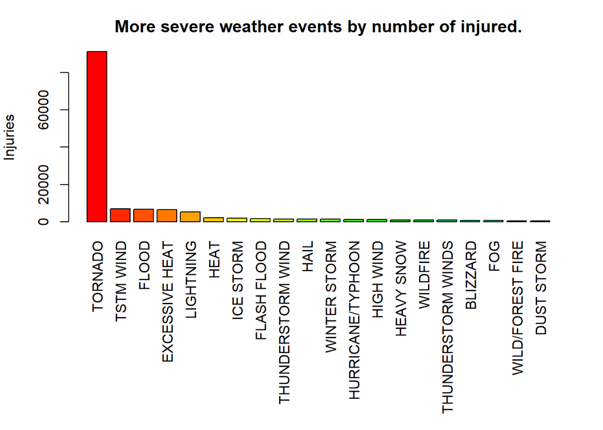

```r
    par(mar = c(12,4,3,2), las = 3)
    barplot(totalinjsort$Injuries[1:20], names.arg = totalinjsort$Event[1:20],
            col = rainbow (20, start=0, end=0.5), main = "More severe weather events by number of injured.",
            ylab = "Injuries")
```

More severe weather events by number of fatalities.

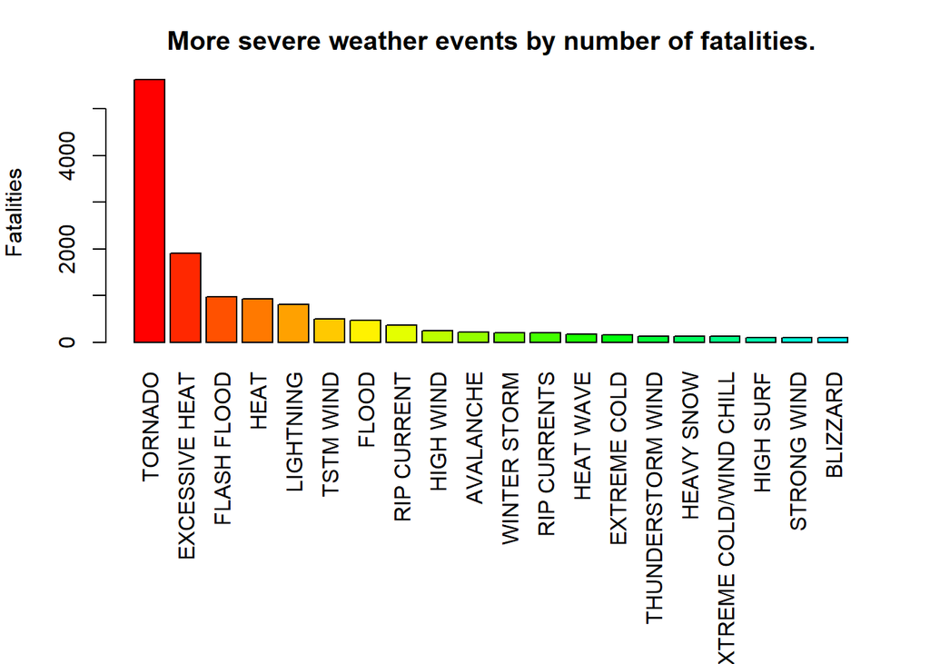

```r
    par(mar = c(12,4,3,2), las = 3)
    barplot(totalfatsort$Fatalities[1:20], names.arg = totalfatsort$Event[1:20],
            col = rainbow (20, start=0, end=0.5), main = "More severe weather events by number of fatalities.",
            ylab = "Fatalities")
```

#### 2.- Economic impact

Total economic impact of ordered by event

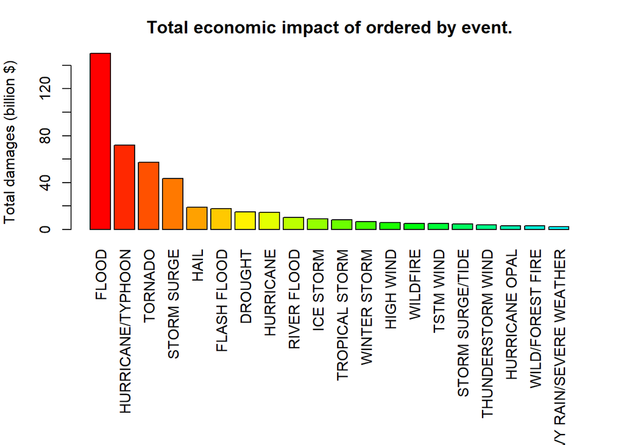

```r
    par(mar = c(12,4,3,2), las = 3)
    barplot(totaldamsort$cropandpropdam[1:20]/1e9, names.arg = totaldamsort$Event[1:20],
            col = rainbow (20, start=0, end=0.5), main = "Total economic impact of ordered by event.",
            ylab = "Total damages (billion $)")
```